# Análisis de Eficacia y Coste Goleador — Temporada 2024-25

**Bienvenido/a**. Este cuaderno explora el rendimiento ofensivo y la rentabilidad salarial de **11 atacantes destacados** de la liga 2024-25.  
A lo largo del análisis responderemos a tres preguntas clave:

1. **¿Quién genera más goles y con qué frecuencia?**
   - Goles totales
   - Goles / Partido
   - Goles / Tiro
2. **¿Cuán certeros son sus remates?**
   - Goles / Partido
   - Goles / tiro
3. **¿Cuánto cuesta cada gol o disparo?**
   - Euros / Gol
   - Euros / Tiro
   - Euros / Tiro a Puerta

## Variables del dataset

**Volumen de juego**

- **Partidos** | Encuentros disputados
- **Minutos** | Minutos totales sobre el césped

**Producción ofensiva**

- **Goles** | Goles marcados en la temporada
- **Tiros** | Disparos totales intentados
- **Tiros a Puerta** | Disparos que fueron a portería

**Economía**

- **Salarios (€)** | Salario anual estimado

Estas métricas permiten comparar **eficiencia goleadora** y **rentabilidad económica** de estos 11 futbolistas destacados de esta temporada, y constituyen el hilo conductor de los gráficos y tablas posteriores.

Los datos han sido recopilados de las siguientes páginas:

- Transferkmark
- Capology
- Fotmob

## Jugadores

- Mbappe
- Raphinha
- Lamine
- Vinicius
- Julian_Alv
- Lewandowsky
- Budimir
- Ayoze
- Sorloth
- Ferran
- Sancet

```python
import pandas as pd
import numpy as np
import matplotlib.pyplot as plt
pd.options.display.float_format = '{:,.2f}'.format
```

### Creación del DataFrame **`jugadores`**

Los valores de goles, tiros, minutos y salarios se han recopilado a partir de:

- **Transfermarkt** – estadísticas de partidos y minutos.
- **FotMob** – desglose de disparos (totales y a puerta).
- **Capology** – estimaciones salariales de la temporada 2023-24.

Este DataFrame será la base para todos los cálculos y gráficos del cuaderno.

```python
# Jugadores
jugadores = pd.DataFrame({
    'Goles': [31, 18, 9, 11, 17, 27, 21, 19, 20,10,15],
    'Tiros': [161, 114, 144, 81, 74, 115, 99, 75, 79,48,50],
    'Tiros a Puerta': [85, 43, 47, 28, 41, 48, 37, 31,42,22,20],
    'Partidos': [34, 36, 35, 30, 37, 34, 38, 30, 35,27,29],
    'Minutos':[2195,2844,2861,2257,2518,2681,2966,1977,1560,1100,1626],
    'Salarios': [71600000, 14580000, 27090000, 25000000, 8320000, 33330000, 1350000, 2080000, 6240000,13000000,2500000]
}, index=["Mbappe", "Raphinha", "Lamine", "Vinicius", "Julian_Alv", "Lewandowsky", "Budimir", "Ayoze", "Sorloth","Ferran","Sancet"])
jugadores
```

|  | Goles | Tiros | Tiros a Puerta | Partidos | Minutos | Salarios |
| --- | --- | --- | --- | --- | --- | --- |
| Mbappe | 31 | 161 | 85 | 34 | 2195 | 71600000 |
| Raphinha | 18 | 114 | 43 | 36 | 2844 | 14580000 |
| Lamine | 9 | 144 | 47 | 35 | 2861 | 27090000 |
| Vinicius | 11 | 81 | 28 | 30 | 2257 | 25000000 |
| Julian_Alv | 17 | 74 | 41 | 37 | 2518 | 8320000 |
| Lewandowsky | 27 | 115 | 48 | 34 | 2681 | 33330000 |
| Budimir | 21 | 99 | 37 | 38 | 2966 | 1350000 |
| Ayoze | 19 | 75 | 31 | 30 | 1977 | 2080000 |
| Sorloth | 20 | 79 | 42 | 35 | 1560 | 6240000 |
| Ferran | 10 | 48 | 22 | 27 | 1100 | 13000000 |
| Sancet | 15 | 50 | 20 | 29 | 1626 | 2500000 |

### Configuración y métricas base

Esta celda prepara todas las variables reutilizadas en los gráficos posteriores.

```python
colores_jugadores = {
    'Mbappe': 'white',
    'Raphinha': 'purple',
    'Lamine': 'purple',
    'Vinicius': 'white',
    'Julian_Alv': 'red',
    'Lewandowsky': 'purple',
    'Budimir': 'brown',
    'Ayoze': 'yellow',
    'Sorloth': 'red',
    'Ferran':'purple',
    'Sancet':'red',
}


jugadores["Goles por Tiro"]    = jugadores["Goles"] / jugadores["Tiros"]
jugadores["Costo por Gol"]     = jugadores["Salarios"] / jugadores["Goles"]
jugadores["Costo por Tiro"]    = jugadores["Salarios"] / jugadores["Tiros"]
jugadores["Goles por Partido"] = jugadores["Goles"] / jugadores["Partidos"].replace(0, np.nan)


#  Rankings
top10 = jugadores.sort_values("Goles", ascending=False).head(11)

jugadores_ordenado_gp   = jugadores.sort_values("Goles por Partido", ascending=False)
goles_partido           = jugadores_ordenado_gp["Goles por Partido"]
goles_total_liga = 995
goles_jugadores  = jugadores["Goles"].sum()
goles_resto      = goles_total_liga - goles_jugadores

tamaños   = jugadores["Goles"].tolist() + [goles_resto]
etiquetas = jugadores.index.tolist() + ["Resto de la liga"]

jugadores_ordenado_gt = jugadores.sort_values("Goles por Tiro",ascending=False)
goles_tiro  = jugadores_ordenado_gt["Goles por Tiro"]


tiros_totales = jugadores_ordenado_gt['Tiros'].tolist()
goles = jugadores_ordenado_gt['Goles'].tolist()
nombres = jugadores_ordenado_gt.index.tolist()
partidos_jugados = jugadores_ordenado_gt['Partidos'].tolist()
goles_por_tiro = jugadores_ordenado_gt['Goles por Tiro'].tolist()

nombres = top10.index.tolist()
goles = top10['Goles'].tolist()
partidos = top10['Partidos'].tolist()



#  Listas de colores (protegidas con .get para no romper si falta algún nombre)
colores_top10           = [colores_jugadores.get(n, "gray") for n in top10.index]
colores_gpp             = [colores_jugadores.get(n, "gray") for n in jugadores_ordenado_gp.index]
colores_gptiro          = [colores_jugadores.get(n, "gray") for n in jugadores_ordenado_gt.index]


colores_pie = colores_top10 + ["orange"]
```

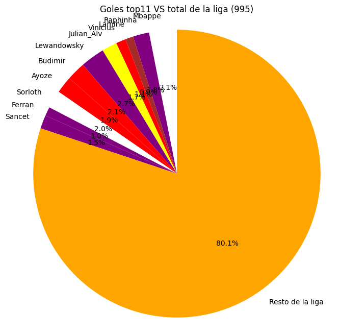

```python
# Gráfico
plt.figure(figsize=(8, 8))
plt.pie(
    tamaños,
    labels=etiquetas,
    autopct="%1.1f%%",
    startangle=90,
    colors=colores_pie
)
plt.title("Goles top11 VS total de la liga (995)")
plt.axis("equal")
plt.show()
```

### Goles vs Partidos de los 11 máximos anotadores

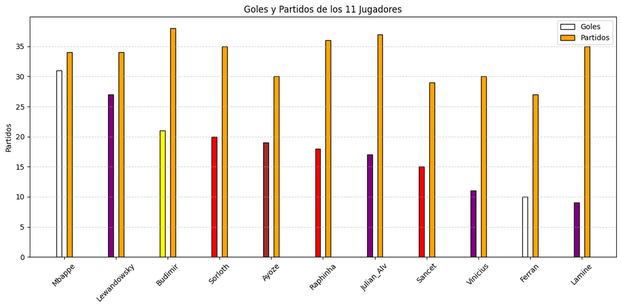

```python
#  Posiciones

x = np.arange(len(nombres))
width = 0.1

# Gráfico
plt.figure(figsize=(12, 6))
plt.bar(x - width, goles, width=width, label='Goles', color=colores_gpp, edgecolor='black')
plt.bar(x + width, partidos, width=width, label='Partidos', color='orange', edgecolor='black')

# Estilo
plt.xticks(x, nombres, rotation=45)
plt.ylabel('Partidos')
plt.title('Goles y Partidos de los 11 Jugadores')
plt.legend()
plt.tight_layout()
plt.grid(axis='y', linestyle='--', alpha=0.5)
plt.show()
```

### Goles por Jugador

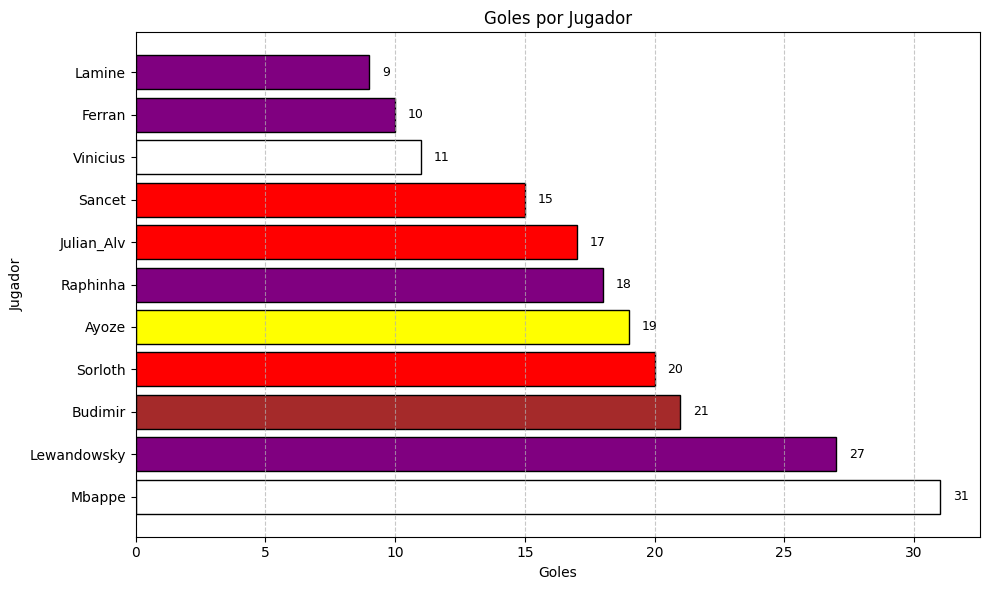

```python
#  Gráfico
plt.figure(figsize=(10, 6))
plt.barh(nombres, goles, color=colores_top10, edgecolor='black')

#  Añadir etiquetas al final de cada barra
for i, valor in enumerate(goles):
    plt.text(valor + 0.5, i, f"{valor}", va='center', fontsize=9)

# Estilo
plt.title('Goles por Jugador')
plt.xlabel('Goles')
plt.ylabel('Jugador')
plt.grid(axis='x', linestyle='--', alpha=0.7)
plt.tight_layout()
plt.show()
```

### Goles por partido

En este gráfico de barras horizontales evaluamos la **capacidad de goleadora** de cada jugador por partido.

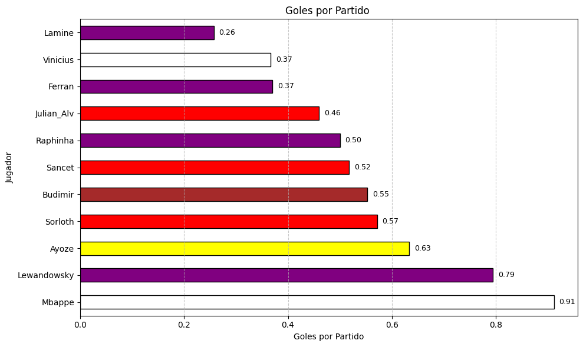

```python
#  Crear lista de colores alineada
colores = [colores_jugadores[nombre] for nombre in goles_partido.index]

#  Grafico
plt.figure(figsize=(10, 6))
ax = goles_partido.plot(kind='barh', color=colores, edgecolor='black')

#  Etiquetas al final de cada barra
for i, (valor, nombre) in enumerate(zip(goles_partido, goles_partido.index)):
    ax.text(valor + 0.01, i, f"{valor:.2f}", va='center', fontsize=9)

#  Estilo
plt.title('Goles por Partido ')
plt.xlabel('Goles por Partido')
plt.ylabel('Jugador')
plt.grid(axis='x', linestyle='--', alpha=0.7)
plt.tight_layout()
plt.show()
```

### Eficiencia goleadora VS Número de partidos

[figure not shown]

```python
#  Grafico
plt.figure(figsize=(10, 6))

plt.scatter(partidos, nombres,
            s=700,
            color='forestgreen',
            edgecolors='white')

#  Añadir etiquetas dentro de cada punto
for x, y, g in zip(partidos, nombres, goles_partido):
    plt.text(x, y, f'{g:.2f}', va='center', ha='center',
             fontsize=9, color='white', fontweight='bold')

# Estética
plt.title('Goles por Partido vs. Partidos Jugados (ordenados por eficiencia)')
plt.xlabel('Partidos jugados')
plt.xlim(25, 39)
plt.ylabel('Jugador')
plt.grid(axis='x', linestyle='--', alpha=0.6)
plt.tight_layout()
plt.show()
```

### Tabla de eficiencia goleadora

Este bloque crea un DataFrame **eficiencia** que resume lo productivo que es cada jugador en términos de goles por partido.

```python
#  DataFrame
eficiencia = goles_partido.rename("G/P").to_frame()

# Partidos necesarios por gol
eficiencia["Part./Gol"] = (1 / eficiencia["G/P"]).round(2)

# Clasificación textual
def interpretar(ratio):
    if ratio >= 0.8:
        return "Marca prácticamente cada partido. Nivel élite."
    elif ratio >= 0.6:
        return "≈1 gol cada 1-1.6 partidos. Ratio alto."
    elif ratio >= 0.4:
        return "≈1 gol cada 2 partidos. Rendimiento sólido."
    elif ratio >= 0.3:
        return "≈1 gol cada 3 partidos. Ratio medio."
    else:
        return "≈1 gol cada 4+ partidos. Aporta más en creación."

eficiencia["Conclusión"] = eficiencia["G/P"].apply(interpretar)

# Ordenar de mayor a menor eficiencia
eficiencia = eficiencia.sort_values("G/P", ascending=False)

eficiencia
```

|  | G/P | Part./Gol | Conclusión |
| --- | --- | --- | --- |
| Mbappe | 0.91 | 1.10 | Marca prácticamente cada partido. Nivel élite. |
| Lewandowsky | 0.79 | 1.26 | ≈1 gol cada 1-1.6 partidos. Ratio alto. |
| Ayoze | 0.63 | 1.58 | ≈1 gol cada 1-1.6 partidos. Ratio alto. |
| Sorloth | 0.57 | 1.75 | ≈1 gol cada 2 partidos. Rendimiento sólido. |
| Budimir | 0.55 | 1.81 | ≈1 gol cada 2 partidos. Rendimiento sólido. |
| Sancet | 0.52 | 1.93 | ≈1 gol cada 2 partidos. Rendimiento sólido. |
| Raphinha | 0.50 | 2.00 | ≈1 gol cada 2 partidos. Rendimiento sólido. |
| Julian_Alv | 0.46 | 2.18 | ≈1 gol cada 2 partidos. Rendimiento sólido. |
| Ferran | 0.37 | 2.70 | ≈1 gol cada 3 partidos. Ratio medio. |
| Vinicius | 0.37 | 2.73 | ≈1 gol cada 3 partidos. Ratio medio. |
| Lamine | 0.26 | 3.89 | ≈1 gol cada 4+ partidos. Aporta más en creación. |

### Goles por Tiro

Este bloque visualiza la eficacia de remate de cada jugador mediante un gráfico de barras horizontales, donde el valor representado es **goles anotados por cada disparo** realizado.

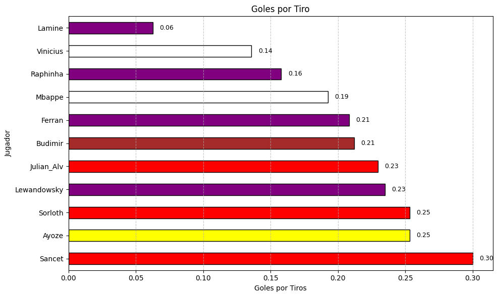

```python
#  Grafico
plt.figure(figsize=(10,6))
ax = goles_tiro.plot(kind='barh', color=colores_gptiro   , edgecolor='black')

#  Añadir etiquetas al final de cada barra
for i, (valor, nombre) in enumerate(zip(goles_tiro, goles_tiro.index)):
    ax.text(valor + 0.005, i, f"{valor:.2f}", va='center', fontsize=9)

#  Estilo
plt.title('Goles por Tiro')
plt.xlabel('Goles por Tiros')
plt.ylabel('Jugador')
plt.grid(axis='x', linestyle='--', alpha=0.7)
plt.tight_layout()
plt.show()
```

### Volumen de tiro VS producción goleadora

[figure not shown]

```python
# Gráfico
plt.figure(figsize=(10, 6))

plt.scatter(tiros_totales, goles,
            s=200,
            color='forestgreen',
            edgecolors='white')

#  Texto en cada punto (nombre + partidos)
for x, y, nombre, partidos in zip(tiros_totales, goles, nombres, partidos_jugados):
    plt.text(x, y, f'{nombre}\n{partidos} partidos',
             va='center', ha='center', fontsize=9,
             color='black', fontweight='bold')

# Estilo
plt.title('Tiros Totales vs Goles\n(Eficiencia: Goles por Tiro)')
plt.xlabel('Tiros Totales')
plt.ylabel('Goles')
plt.xlim(min(tiros_totales) - 5, max(tiros_totales) + 10)
plt.ylim(min(goles) - 2, max(goles) + 5)
plt.grid(axis='both', linestyle='--', alpha=0.6)
plt.tight_layout()
plt.show()
```

### Tabla de precisión de tiro

El DataFrame **`eficiencia_tiro`** cuantifica la capacidad de cada jugador para transformar disparos en goles.

```python
eficiencia_tiro = goles_tiro.rename("G/T").to_frame()         # G/T = goles por tiro

#  Tiros necesarios por gol (inversa)
eficiencia_tiro["Tiros/Gol"] = (1 / eficiencia_tiro["G/T"]).round(1)

#  Clasificación textual
def clasificar(r):
    if r >= 0.30:
        return "Élite (convierte ≥30 % de sus disparos)"
    elif r >= 0.25:
        return "Muy buena (convierte el 25-29 de sus disparos %)"
    elif r >= 0.20:
        return "Buena (convierte el 20-24 de sus disparos %)"
    elif r >= 0.15:
        return "Media (convierte el 15-19de sus disparos%)"
    else:
        return "Baja (convierte el <15 de sus disparos%)"

eficiencia_tiro["Conclusión"] = eficiencia_tiro["G/T"].apply(clasificar)

#  Ordenar de mayor a menor eficiencia
eficiencia_tiro = eficiencia_tiro.sort_values("G/T", ascending=False)

#  Mostrar
eficiencia_tiro
```

|  | G/T | Tiros/Gol | Conclusión |
| --- | --- | --- | --- |
| Sancet | 0.30 | 3.30 | Élite (convierte ≥30 % de sus disparos) |
| Ayoze | 0.25 | 3.90 | Muy buena (convierte el 25-29 de sus disparos %) |
| Sorloth | 0.25 | 4.00 | Muy buena (convierte el 25-29 de sus disparos %) |
| Lewandowsky | 0.23 | 4.30 | Buena (convierte el 20-24 de sus disparos %) |
| Julian_Alv | 0.23 | 4.40 | Buena (convierte el 20-24 de sus disparos %) |
| Budimir | 0.21 | 4.70 | Buena (convierte el 20-24 de sus disparos %) |
| Ferran | 0.21 | 4.80 | Buena (convierte el 20-24 de sus disparos %) |
| Mbappe | 0.19 | 5.20 | Media (convierte el 15-19de sus disparos%) |
| Raphinha | 0.16 | 6.30 | Media (convierte el 15-19de sus disparos%) |
| Vinicius | 0.14 | 7.40 | Baja (convierte el <15 de sus disparos%) |
| Lamine | 0.06 | 16.00 | Baja (convierte el <15 de sus disparos%) |

### Rentabilidad goleadora — Euros por Gol

La siguiente tabla clasifica a cada jugador según **cuánto cuesta cada gol** marcado

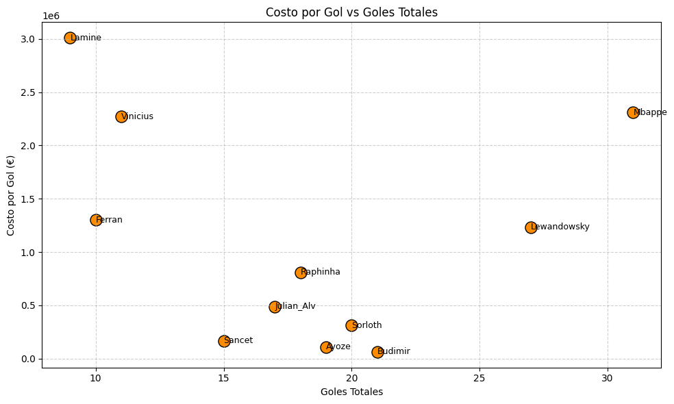

```python
#  Gráfico
plt.figure(figsize=(10, 6))
plt.scatter(jugadores['Goles'], jugadores['Costo por Gol'], color='darkorange', edgecolors='black', s=150)

# Etiquetas
for nombre, x, y in zip(jugadores.index, jugadores['Goles'], jugadores['Costo por Gol']):
    plt.text(x, y, nombre, fontsize=9, va='center', ha='left')

plt.title('Costo por Gol vs Goles Totales')
plt.xlabel('Goles Totales')
plt.ylabel('Costo por Gol (€)')
plt.grid(True, linestyle='--', alpha=0.6)
plt.tight_layout()
plt.show()
```

```python
jugadores["Costo por Gol"]
```

```
Mbappe        2,309,677.42
Raphinha        810,000.00
Lamine        3,010,000.00
Vinicius      2,272,727.27
Julian_Alv      489,411.76
Lewandowsky   1,234,444.44
Budimir          64,285.71
Ayoze           109,473.68
Sorloth         312,000.00
Ferran        1,300,000.00
Sancet          166,666.67
Name: Costo por Gol, dtype: float64
```

### Euros por Gol — ¿Qué tan caro resulta cada tanto?

La tabla **`euros_gol`** compara lo que paga el club por cada gol que marca cada jugador

```python
#  DataFrame
euros_gol = jugadores["Costo por Gol"].rename("€ por Gol").to_frame()

#  Formato monetario opcional (miles con coma)
euros_gol["€ por Gol"] = euros_gol["€ por Gol"].round(0).astype(int)

#  Clasificación textual
def costo(euros):
    if euros <= 250_000:
        return "Eficiencia sobresaliente"
    elif euros <= 750_000:
        return "Buen precio"
    elif euros <= 1_500_000:
        return "Costo medio"
    else:
        return "Gol de lujo"

euros_gol["Conclusión"] = euros_gol["€ por Gol"].apply(costo)

#  Ordenar de menor a mayor coste por gol
euros_gol = euros_gol.sort_values("€ por Gol")

euros_gol
```

|  | € por Gol | Conclusión |
| --- | --- | --- |
| Budimir | 64286 | Eficiencia sobresaliente |
| Ayoze | 109474 | Eficiencia sobresaliente |
| Sancet | 166667 | Eficiencia sobresaliente |
| Sorloth | 312000 | Buen precio |
| Julian_Alv | 489412 | Buen precio |
| Raphinha | 810000 | Costo medio |
| Lewandowsky | 1234444 | Costo medio |
| Ferran | 1300000 | Costo medio |
| Vinicius | 2272727 | Gol de lujo |
| Mbappe | 2309677 | Gol de lujo |
| Lamine | 3010000 | Gol de lujo |

### Rentabilidad goleadora — Euros por tiro

La siguiente tabla clasifica a cada jugador según **cuánto cuesta cada tiro** realizado.

[figure not shown]

```python
#  Gráfico
plt.figure(figsize=(10, 6))
plt.scatter(jugadores['Goles'], jugadores['Costo por Tiro'], color='darkorange', edgecolors='black', s=150)

#  Etiquetas
for nombre, x, y in zip(jugadores.index, jugadores['Goles'], jugadores['Costo por Tiro']):
    plt.text(x, y, nombre, fontsize=9, va='center', ha='left')

plt.title('Costo por Tiro vs Tiro Totales')
plt.xlabel('Tiros Totales')
plt.ylabel('Costo por Tiro (€)')
plt.grid(True, linestyle='--', alpha=0.6)
plt.tight_layout()
plt.show()
```

```python
jugadores['Costo por Tiro']
```

```
Mbappe        444,720.50
Raphinha      127,894.74
Lamine        188,125.00
Vinicius      308,641.98
Julian_Alv    112,432.43
Lewandowsky   289,826.09
Budimir        13,636.36
Ayoze          27,733.33
Sorloth        78,987.34
Ferran        270,833.33
Sancet         50,000.00
Name: Costo por Tiro, dtype: float64
```

### Euros por Tiro — ¿Qué tan caro resulta cada tiro?

La tabla **`euros_tiro`** compara lo que paga el club por cada tiro de cada jugador

```python
#  DataFrame
euros_tiro = jugadores["Costo por Tiro"].rename("€ por Tiro").to_frame()

#  Redondeo a euros enteros (opcional)
euros_tiro["€ por Tiro"] = euros_tiro["€ por Tiro"].round(0).astype(int)

#  Clasificación textual
def clasificar_ct(euros):
    if euros <= 50_000:
        return "Muy barato (≤ 50 k €)"
    elif euros <= 150_000:
        return "Barato (51 k – 150 k €)"
    elif euros <= 400_000:
        return "Coste medio (151 k – 400 k €)"
    else:
        return "Disparo de lujo (> 400 k €)"

euros_tiro["Conclusión"] = euros_tiro["€ por Tiro"].apply(clasificar_ct)

# Ordenar de más barato a más caro
euros_tiro = euros_tiro.sort_values("€ por Tiro", ascending=False)
euros_tiro
```

|  | € por Tiro | Conclusión |
| --- | --- | --- |
| Mbappe | 444720 | Disparo de lujo (> 400 k €) |
| Vinicius | 308642 | Coste medio (151 k – 400 k €) |
| Lewandowsky | 289826 | Coste medio (151 k – 400 k €) |
| Ferran | 270833 | Coste medio (151 k – 400 k €) |
| Lamine | 188125 | Coste medio (151 k – 400 k €) |
| Raphinha | 127895 | Barato (51 k – 150 k €) |
| Julian_Alv | 112432 | Barato (51 k – 150 k €) |
| Sorloth | 78987 | Barato (51 k – 150 k €) |
| Sancet | 50000 | Muy barato (≤ 50 k €) |
| Ayoze | 27733 | Muy barato (≤ 50 k €) |
| Budimir | 13636 | Muy barato (≤ 50 k €) |

### Euros por Tiro a Puerta — ¿Qué tan caro resulta cada tiro a puerta ?

La tabla **`euros_tiro_puerta`** compara lo que paga el club por cada tiro a puerta de cada jugador

```python
#  DataFrame
euros_tiro_puerta = (jugadores["Salarios"] / jugadores["Tiros a Puerta"]) \
                       .rename("€ por Tiro a Puerta") \
                       .to_frame()

#  Redondeo a euros enteros (opcional)
euros_tiro_puerta["€ por Tiro a Puerta"] = (
    euros_tiro_puerta["€ por Tiro a Puerta"].round(0).astype(int)
)

#  Clasificación textual  ─ ajustes según tu rango real de costes
def clasificar_tp(euros):
    if euros <= 100_000:
        return "Muy barato (≤ 100 k €)"
    elif euros <= 250_000:
        return "Barato (101 k – 250 k €)"
    elif euros <= 600_000:
        return "Coste medio (251 k – 600 k €)"
    else:
        return "Disparo a puerta de lujo (> 600 k €)"

euros_tiro_puerta["Conclusión"] = euros_tiro_puerta["€ por Tiro a Puerta"].apply(clasificar_tp)

#  Ordenar de menor a mayor coste
euros_tiro_puerta = euros_tiro_puerta.sort_values("€ por Tiro a Puerta", ascending=False)

euros_tiro_puerta
```

|  | € por Tiro a Puerta | Conclusión |
| --- | --- | --- |
| Vinicius | 892857 | Disparo a puerta de lujo (> 600 k €) |
| Mbappe | 842353 | Disparo a puerta de lujo (> 600 k €) |
| Lewandowsky | 694375 | Disparo a puerta de lujo (> 600 k €) |
| Ferran | 590909 | Coste medio (251 k – 600 k €) |
| Lamine | 576383 | Coste medio (251 k – 600 k €) |
| Raphinha | 339070 | Coste medio (251 k – 600 k €) |
| Julian_Alv | 202927 | Barato (101 k – 250 k €) |
| Sorloth | 148571 | Barato (101 k – 250 k €) |
| Sancet | 125000 | Barato (101 k – 250 k €) |
| Ayoze | 67097 | Muy barato (≤ 100 k €) |
| Budimir | 36486 | Muy barato (≤ 100 k €) |

### Comparación de Tablas

Tabla combinada que muestra el coste por tiro, el coste por tiro a puerta.

```python
comparacion_tablas = pd.concat([euros_tiro, euros_tiro_puerta], axis=1)

# Valor absoluto y ratio
comparacion_tablas["Δ absoluto (€)"] = (
    comparacion_tablas["€ por Tiro a Puerta"] -
    comparacion_tablas["€ por Tiro"]
).round(0).astype(int)

comparacion_tablas["Ratio TP/T"] = (
    comparacion_tablas["€ por Tiro a Puerta"] /
    comparacion_tablas["€ por Tiro"]
).round(2)

#  Ordenar si se desea (menor coste primero)

comparacion_tablas = comparacion_tablas.sort_values("€ por Tiro")

comparacion_tablas
```

|  | € por Tiro | Conclusión | € por Tiro a Puerta | Conclusión | Δ absoluto (€) | Ratio TP/T |
| --- | --- | --- | --- | --- | --- | --- |
| Budimir | 13636 | Muy barato (≤ 50 k €) | 36486 | Muy barato (≤ 100 k €) | 22850 | 2.68 |
| Ayoze | 27733 | Muy barato (≤ 50 k €) | 67097 | Muy barato (≤ 100 k €) | 39364 | 2.42 |
| Sancet | 50000 | Muy barato (≤ 50 k €) | 125000 | Barato (101 k – 250 k €) | 75000 | 2.50 |
| Sorloth | 78987 | Barato (51 k – 150 k €) | 148571 | Barato (101 k – 250 k €) | 69584 | 1.88 |
| Julian_Alv | 112432 | Barato (51 k – 150 k €) | 202927 | Barato (101 k – 250 k €) | 90495 | 1.80 |
| Raphinha | 127895 | Barato (51 k – 150 k €) | 339070 | Coste medio (251 k – 600 k €) | 211175 | 2.65 |
| Lamine | 188125 | Coste medio (151 k – 400 k €) | 576383 | Coste medio (251 k – 600 k €) | 388258 | 3.06 |
| Ferran | 270833 | Coste medio (151 k – 400 k €) | 590909 | Coste medio (251 k – 600 k €) | 320076 | 2.18 |
| Lewandowsky | 289826 | Coste medio (151 k – 400 k €) | 694375 | Disparo a puerta de lujo (> 600 k €) | 404549 | 2.40 |
| Vinicius | 308642 | Coste medio (151 k – 400 k €) | 892857 | Disparo a puerta de lujo (> 600 k €) | 584215 | 2.89 |
| Mbappe | 444720 | Disparo de lujo (> 400 k €) | 842353 | Disparo a puerta de lujo (> 600 k €) | 397633 | 1.89 |